## Loading data

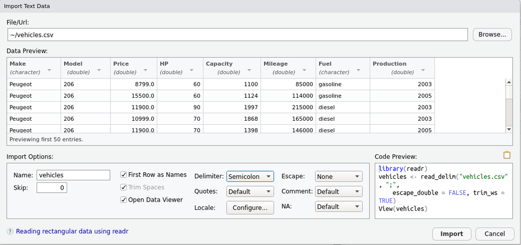

An example of the RStudio program window for importing data using a graphical interface.

If we encounter an untypical file formatting, we can use a few control buttons to specify what the separator is, whether the first row contains headers etc.

If we do not use RStudio, we can use function `read.table()` to load data. An example of this function is given below.

File http://www.biecek.pl/R/auta.csv contains data on 2400 sales offers for cars of different makes. This data is stored in a file with .csv extension. Each offer contains 8 parameters which are separated with semicolons in the text file.

A fragment of the file is shown below.

```
"Make";"Model";"Price";"HP";"Capacity";"Mileage";"Fuel";"
Production"
"Peugeot";"206";8799;60;1100;85000;"gasoline";2003
"Peugeot";"206";15500;60;1124;114000;"gasoline";2005
"Peugeot";"206";11900;90;1997;215000;"diesel";2003
"Peugeot";"206";10999;70;1868;165000;"diesel";2003
"Peugeot";"206";11900;70;1398;146000;"diesel";2005
"Peugeot";"206";19900;70;1398;86400;"diesel";2006
...
```

The first argument of `read.table()` is the path to the file with the data. The file can be located on a hard drive, or on the Internet.

The next two arguments in the function execution below specify that the values in subsequent columns are separated with semicolons, and that the first row contains variable names.

The result of function `read.table()` – the table with data – is assigned to the vehicles symbol using the <- operator.

```r
vehicles <- read.table("vehicles.csv",
                       sep = ";", header = TRUE)
head(vehicles)
```

```
##      Make Model Price HP Capacity Mileage     Fuel Production
## 1 Peugeot   206  8799 60     1100   85000 gasoline       2003
## 2 Peugeot   206 15500 60     1124  114000 gasoline       2005
## 3 Peugeot   206 11900 90     1997  215000   diesel       2003
## 4 Peugeot   206 10999 70     1868  165000   diesel       2003
## 5 Peugeot   206 11900 70     1398  146000   diesel       2005
## 6 Peugeot   206 19900 70     1398   86400   diesel       2006
```

The `head()` function shows the first 6 rows from the data set. This function allows us to quickly find out what the table contains.

In Section 2.6 we discuss more methods of data loading using various formats.

Once we have our data in place, it is time to work with it.